## *Group: Aysha Asmeth & Aditya Sabu*

# Guide to Making an NBA Superstar

- **1) Introduction**
- **2) Loading Data**
  - 2.1) Importing Required Libraries
  - 2.2) Importing Data into Dataframe
  - 2.3) Tidying Data
- **3) Isolating Top 25 Players**
- **4) Defining VI and ORTG**
  - 4.1) TS% (True Shooting Percentage)
  - 4.2) Assists and Rebounds Per Game
    - 4.2.a) Assists
    - 4.2.b) Rebounds
- **5) Model Creation**
- **6) Conclusions**

# 1) Introduction

The NBA (National Basketball Association) is now in an era where the game is played at a much faster pace therefore leading to more possesions per game. Compared to an era such as the 90s where physicality and team defense were the biggest factors which determined if a team could be successful or not, the ideologies for what makes successful players and teams have changed greatly.

The rebirth of "small ball" via the "Death Lineup", a lineup employed by coach Steve Kerr of the Golden State Warriors from 2014-2019 relied on athleticism, fast pace, elite 3 point shooting, floor spacing, and a non-traditional center (a center < 6ft 11, the league average height for NBA centers). This lineup led on the floor primarily by Stephen Curry (along with Klay Thompson and Draymond Green) completely shifted the landscape of the league and changed the way NBA organizations constructed their rosters.

As a result, teams started to invest more in offense as the foundation of their teams. For example, Oklahoma University basketball star Trae Young's stock in the 2018 NBA draft skyrocketed because of his comparisons to Steph Curry due to his body structure and 3 point marksmanship. Trae Young, 6'2" and a top-10 draft pick just based off of raw talent alone, would've most likely not been drafted above other traditional high prospects most notably Luka Doncic (who ended up winning Rookie of the Year) if it weren't for the Curry effect is a perfect example of how the NBA started focusing on offense more.

Interestingly in the midst of this Curry era wherein perimeter (3-point) shooting had been supremely focused in on there was also a rebirth of the center and power forward ('big men') positions as well. Players like Joel Embiid, Giannis Antetokounmpo, Anthony Davis, and Nikola Jokic have been at the reigns for this movement. Traditional big men's roles in the 80s and 90s consisted solely of rebounding and defense, however in this new era big men like the ones mentioned above started becoming more versatile. These players worked to becoming not only rebounding threats and scoring in the paint (area up until 15ft away from the basket), but also as perimeter scorers, athletic scorers, and playmakers as well.

These skills pave the way for more efficient offense because when big men become perimeter scoring threats it means the other elite shooters on the team will get more 1-on-1 matchups and space on the floor to work with to get their optimal shots as the opposing team can not afford to leave the big men unguarded due to their outside shooting ability. This also gives more space in the paint area for these shooting guards to, either, drive in and score or get fouled and go to the free throw line. As big men become more athletic and improve their playmaking skills defending them becomes a lot harder as the opposing team has to take into consideration their passing ability to create shots for others along with their dominance and strength to muscle away other players as they make their way closer to the basket for higher efficiency shots (i.e. dunks and layups).

*Due to these trends, defining a superstar in this league is now becoming hand-in-hand with the ability produce offense for oneself and for the team. In this guide, We'll illustrate how this idea of elite scoring/offensive skills factor into the statistics of the top players of the league, and how these statistics should be interpreted as we dive deeper into the meaning/value of these statistics*

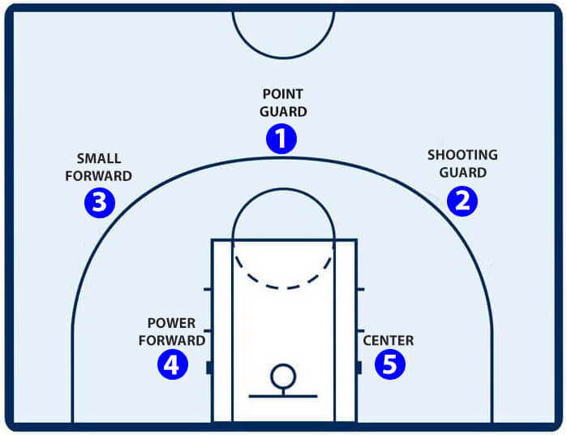

The picture above depicts the standard team's lineup layout and the areas each position generally spend most of their possesions around.

# 2) Loading Data into Usable Form

## 2.1) Importing Required Libraries

```python
# The libraries I will be using throughout the this tutorial can be found here
import pandas as pd
import numpy as np
import matplotlib.pyplot as plt
import seaborn as sns
from sklearn.linear_model import LinearRegression
from sklearn import model_selection
from sklearn.linear_model import LogisticRegression
from sklearn.svm import SVC
from sklearn.ensemble import RandomForestClassifier
from sklearn.model_selection import cross_val_score
from sklearn.model_selection import train_test_split

# This shows all of the first 30 columns of a dataframe
pd.set_option('display.max_columns', 30)
```

- Pandas: used for data display and partitioning
- Matplotlib - pyplot: used for plotting Pandas data into graphs and charts
- Seaborn: provides a high-level interface for graphics on top of Matplotlib
- scikit-learn: very popular machine learning library
  - linear-model: used to calculate models for multiple linear regression
  - model_selection: used to split up dataset into test and training data and evaluate predictions

## 2.2) Importing Data into DataFrame

```python
# I loaded my dataset into the dataframe player_stats

loc = '2018-2019_PlayerStats.xlsx'
player_stats = pd.read_excel(loc)
player_stats.head()
```

|  | 2018-2019 NBA Player Stats \| NBAstuffer | Unnamed: 1 | Unnamed: 2 | Unnamed: 3 | Unnamed: 4 | Unnamed: 5 | Unnamed: 6 | Unnamed: 7 | Unnamed: 8 | Unnamed: 9 | Unnamed: 10 | Unnamed: 11 | Unnamed: 12 | Unnamed: 13 | Unnamed: 14 | Unnamed: 15 | Unnamed: 16 | Unnamed: 17 | Unnamed: 18 | Unnamed: 19 | Unnamed: 20 | Unnamed: 21 | Unnamed: 22 | Unnamed: 23 | Unnamed: 24 | Unnamed: 25 | Unnamed: 26 | Unnamed: 27 | Unnamed: 28 |
| --- | --- | --- | --- | --- | --- | --- | --- | --- | --- | --- | --- | --- | --- | --- | --- | --- | --- | --- | --- | --- | --- | --- | --- | --- | --- | --- | --- | --- | --- |
| 0 | RANK | FULL NAME\|Player Name\|Player's Full Name | TEAM\|Player's Team\| Player's Team | POS\|Player's position\| The position the player... | AGE\|Player Age\| Player's age | GP\|Games Played\|Number of games played out of 82 | MPG\|Minutes per game\| Average minutes played p... | MIN%\|Minutes Percentage\|Percentage of team min... | USG%\|Usage Rate\|Usage rate, a.k.a., usage perc... | Tor\|Turnover Rate\|A metric that estimates the ... | FTA\|Free throws attempted\|Total number of free... | FT%\|Free throw percentage\|A stat depicting how... | 2PA\|2 pointers attempted\| The total number of ... | 2P%\|2 point percentage\|Stat depicting how well... | 3PA\|3 pointers attempted\| The total number of ... | 3P%\|3 point percentage\|Stat depicting how well... | eFG%\|Effective Shooting Percentage\|With eFG%, ... | TS%\|True Shooting Percentage\|True shooting per... | PPG\|Points\|Points per game. | RPG\|Rebounds\|Rebounds per game. | TRB%\|Total Rebound Percentage\|Total rebound pe... | APG\|Assists\|Assists per game. | AST%\|Assist Percentage\|Assist percentage is an... | SPG\|Steals\|Steals per game. | BPG\|Blocks\|Blocks per game. | TOPG\|Turnovers\|Turnovers per game. | VI\|Versatility Index\|Versatility index is a me... | ORTG\|Offensive Rating\|Individual offensive rat... | DRTG\|Defensive Rating\|Individual defensive rat... |
| 1 | NaN | James Harden | Hou | G | 29.63 | 78 | 36.8 | 76.6 | 40.5 | 14.5 | 858 | 0.879 | 881 | 0.528 | 1028 | 0.368 | 0.541 | 0.616 | 36.1 | 6.6 | 10 | 7.5 | 39.5 | 2.05 | 0.73 | 4.96 | 13.2 | 118.6 | 103.5 |
| 2 | NaN | Paul George | Okc | F | 28.94 | 77 | 36.9 | 76.9 | 29.5 | 10 | 539 | 0.84 | 856 | 0.485 | 757 | 0.386 | 0.529 | 0.583 | 28 | 8.1 | 11.4 | 4.1 | 17.7 | 2.21 | 0.44 | 2.66 | 10.6 | 116.5 | 100.8 |
| 3 | NaN | Giannis Antetokounmpo | Mil | F | 24.35 | 72 | 32.8 | 68.2 | 32.3 | 14.7 | 686 | 0.729 | 1045 | 0.64 | 203 | 0.256 | 0.599 | 0.643 | 27.7 | 12.5 | 19.4 | 5.9 | 30.3 | 1.26 | 1.53 | 3.71 | 15.5 | 121.6 | 93.9 |
| 4 | NaN | Joel Embiid | Phi | F-C | 25.07 | 64 | 33.7 | 70.1 | 33.3 | 13.3 | 649 | 0.804 | 936 | 0.535 | 263 | 0.3 | 0.517 | 0.593 | 27.5 | 13.6 | 21.4 | 3.7 | 18.4 | 0.72 | 1.91 | 3.55 | 13.2 | 113.7 | 98.7 |

As you can see the dataset is a little messy and needs to be cleaned up. Once it is cleaned up we can use the data for further analysis.

## 2.3) Tidying Data

```python
# Retrieve column names from untidy dataset

column_names = []
for stat in player_stats.iloc[0]:
    stat_str = stat.split('|')
    stat_name = stat_str[0]
    column_names.append(stat_name)
```

```python
# Isolate the statistic's full name and description and push them into their designated arrays
stat_names = []
stat_descriptions = []
for stat in player_stats.iloc[0]:
    stat_str = stat.split('|')
    if len(stat_str) == 3:
        stat_name = stat_str[1]
        stat_descrip = stat_str[2]

        stat_names.append(stat_name)
        stat_descriptions.append(stat_descrip)
```

```python
# Set the column names of the dataframe to the ones which I got after traversing the dataframe in last 2 steps
player_stats.columns = column_names
```

```python
# Drop unnecessary columns
player_stats.drop([0],inplace=True)
player_stats.drop(['RANK'], axis = 1,inplace=True)
```

```python
# View the tidy dataset (note that this is in descending order of player name)
player_stats.head()
```

|  | FULL NAME | TEAM | POS | AGE | GP | MPG | MIN% | USG% | Tor | FTA | FT% | 2PA | 2P% | 3PA | 3P% | eFG% | TS% | PPG | RPG | TRB% | APG | AST% | SPG | BPG | TOPG | VI | ORTG | DRTG |
| --- | --- | --- | --- | --- | --- | --- | --- | --- | --- | --- | --- | --- | --- | --- | --- | --- | --- | --- | --- | --- | --- | --- | --- | --- | --- | --- | --- | --- |
| 1 | James Harden | Hou | G | 29.63 | 78 | 36.8 | 76.6 | 40.5 | 14.5 | 858 | 0.879 | 881 | 0.528 | 1028 | 0.368 | 0.541 | 0.616 | 36.1 | 6.6 | 10 | 7.5 | 39.5 | 2.05 | 0.73 | 4.96 | 13.2 | 118.6 | 103.5 |
| 2 | Paul George | Okc | F | 28.94 | 77 | 36.9 | 76.9 | 29.5 | 10 | 539 | 0.84 | 856 | 0.485 | 757 | 0.386 | 0.529 | 0.583 | 28 | 8.1 | 11.4 | 4.1 | 17.7 | 2.21 | 0.44 | 2.66 | 10.6 | 116.5 | 100.8 |
| 3 | Giannis Antetokounmpo | Mil | F | 24.35 | 72 | 32.8 | 68.2 | 32.3 | 14.7 | 686 | 0.729 | 1045 | 0.64 | 203 | 0.256 | 0.599 | 0.643 | 27.7 | 12.5 | 19.4 | 5.9 | 30.3 | 1.26 | 1.53 | 3.71 | 15.5 | 121.6 | 93.9 |
| 4 | Joel Embiid | Phi | F-C | 25.07 | 64 | 33.7 | 70.1 | 33.3 | 13.3 | 649 | 0.804 | 936 | 0.535 | 263 | 0.3 | 0.517 | 0.593 | 27.5 | 13.6 | 21.4 | 3.7 | 18.4 | 0.72 | 1.91 | 3.55 | 13.2 | 113.7 | 98.7 |
| 5 | LeBron James | Lal | F | 34.28 | 55 | 35.2 | 73.4 | 31.6 | 13.3 | 418 | 0.665 | 768 | 0.582 | 327 | 0.339 | 0.56 | 0.588 | 27.4 | 8.4 | 12.3 | 8.3 | 39.4 | 1.31 | 0.6 | 3.58 | 14.1 | 114.4 | 106.2 |

```python
# Make a legend (via dataframe) for all the statistics
column_names.remove(column_names[0])

legend_df = pd.DataFrame()
legend_df['Abbreviated Stat'] = column_names
legend_df['Full Statistic'] = stat_names
legend_df['Statistic Description'] = stat_descriptions

pd.options.display.max_colwidth = 200
legend_df
```

|  | Abbreviated Stat | Full Statistic | Statistic Description |
| --- | --- | --- | --- |
| 0 | FULL NAME | Player Name | Player's Full Name |
| 1 | TEAM | Player's Team | Player's Team |
| 2 | POS | Player's position | The position the player plays on the court |
| 3 | AGE | Player Age | Player's age |
| 4 | GP | Games Played | Number of games played out of 82 |
| 5 | MPG | Minutes per game | Average minutes played per game (out of 48 mins) |
| 6 | MIN% | Minutes Percentage | Percentage of team minutes used by a player while he was on the floor |
| 7 | USG% | Usage Rate | Usage rate, a.k.a., usage percentage is an estimate of the percentage of team plays used by a player while he was on the floor |
| 8 | Tor | Turnover Rate | A metric that estimates the number of turnovers a player commits per 100 possessions |
| 9 | FTA | Free throws attempted | Total number of free throws attempted |
| 10 | FT% | Free throw percentage | A stat depicting how well a player shoots from the free throw line |
| 11 | 2PA | 2 pointers attempted | The total number of 2 pointers attempted over the season |
| 12 | 2P% | 2 point percentage | Stat depicting how well a player shoots 2 pointers |
| 13 | 3PA | 3 pointers attempted | The total number of 3 pointers attempted over the season |
| 14 | 3P% | 3 point percentage | Stat depicting how well a player shoots 3 pointers |
| 15 | eFG% | Effective Shooting Percentage | With eFG%, three-point shots made are worth 50% more than two-point shots made. eFG% Formula=(FGM+ (0.5 x 3PM))/FGA |
| 16 | TS% | True Shooting Percentage | True shooting percentage is a measure of shooting efficiency that takes into account field goals, 3-point field goals, and free throws. |
| 17 | PPG | Points | Points per game. |
| 18 | RPG | Rebounds | Rebounds per game. |
| 19 | TRB% | Total Rebound Percentage | Total rebound percentage is estimated percentage of available rebounds grabbed by the player while the player is on the court. |
| 20 | APG | Assists | Assists per game. |
| 21 | AST% | Assist Percentage | Assist percentage is an estimated percentage of teammate field goals a player assisted while the player is on the court |
| 22 | SPG | Steals | Steals per game. |
| 23 | BPG | Blocks | Blocks per game. |
| 24 | TOPG | Turnovers | Turnovers per game. |
| 25 | VI | Versatility Index | Versatility index is a metric that measures a player’s ability to produce in points, assists, and rebounds. The average player will score around a five on the index, while top players score above 10 |
| 26 | ORTG | Offensive Rating | Individual offensive rating is the number of points produced by a player per 100 total individual possessions. |
| 27 | DRTG | Defensive Rating | Individual defensive rating estimates how many points the player allowed per 100 possessions he individually faced while staying on the court. |

# 3) Isolating Top 25 Players

As I mentioned in the overview, we are going to look into all the different stats as to what makes a star in the NBA today. To do this I will isolate the top 25 players in decreasing order of Points per Game (PPG) which is a telling statistic to show who some of the big names in the league are. The reason I'm not just taking the top 25 players with the highest offensive ranking is because offensive ranking doesn't quite take into account minutes per game played. For example, the player with the highest offensive ranking is a player who played in 4 minutes in 1 game the entire season. After I get those names I will look further into some of their other meaningful statistics that allow them to not only maintain that scoring average but their Offensive Ranking numbers as well.

After I get those 25 players, I will then sort them according to PPG, VI, and ORTG. Remember offensive rating is defined as *the number of points produced by a player per 100 total individual possessions* and VI (Versatility index) is defined as *a metric that measures a player’s ability to produce in points, assists, and rebounds.* In other words, offensive rating and VI are statistics that measure how much a player contributes to the offense/scoring of the team (including how well he scores). As I go further into my analysis, I will refer to other auxilary statistics that determine the validity and relevance of these 3 stats to the offensive facet of the game.

```python
# Isolate top 25 players in descending order by PPG, VI, and ORTG and initialize into 'top_25' dataframe
top_25 = player_stats.sort_values(['PPG','VI','ORTG'],ascending=False)
```

```python
# Take the first 25 rows of the dataframe (the top 25 players in descending order by PPG)
top_25 = top_25.head(25)
```

```python
# Get rid of stats that are either unnecessary or redundant(i.e. 2PA because we already have 2P%)
top_25.drop(columns = ['AGE','FTA', '2PA', '3PA'],axis=1)
top_25.reset_index(drop=True,inplace=True)
```

```python
# View full dataframe
top_25
```

|  | FULL NAME | TEAM | POS | AGE | GP | MPG | MIN% | USG% | Tor | FTA | FT% | 2PA | 2P% | 3PA | 3P% | eFG% | TS% | PPG | RPG | TRB% | APG | AST% | SPG | BPG | TOPG | VI | ORTG | DRTG |
| --- | --- | --- | --- | --- | --- | --- | --- | --- | --- | --- | --- | --- | --- | --- | --- | --- | --- | --- | --- | --- | --- | --- | --- | --- | --- | --- | --- | --- |
| 0 | James Harden | Hou | G | 29.63 | 78 | 36.8 | 76.6 | 40.5 | 14.5 | 858 | 0.879 | 881 | 0.528 | 1028 | 0.368 | 0.541 | 0.616 | 36.1 | 6.6 | 10 | 7.5 | 39.5 | 2.05 | 0.73 | 4.96 | 13.2 | 118.6 | 103.5 |
| 1 | Paul George | Okc | F | 28.94 | 77 | 36.9 | 76.9 | 29.5 | 10 | 539 | 0.84 | 856 | 0.485 | 757 | 0.386 | 0.529 | 0.583 | 28 | 8.1 | 11.4 | 4.1 | 17.7 | 2.21 | 0.44 | 2.66 | 10.6 | 116.5 | 100.8 |
| 2 | Giannis Antetokounmpo | Mil | F | 24.35 | 72 | 32.8 | 68.2 | 32.3 | 14.7 | 686 | 0.729 | 1045 | 0.64 | 203 | 0.256 | 0.599 | 0.643 | 27.7 | 12.5 | 19.4 | 5.9 | 30.3 | 1.26 | 1.53 | 3.71 | 15.5 | 121.6 | 93.9 |
| 3 | Joel Embiid | Phi | F-C | 25.07 | 64 | 33.7 | 70.1 | 33.3 | 13.3 | 649 | 0.804 | 936 | 0.535 | 263 | 0.3 | 0.517 | 0.593 | 27.5 | 13.6 | 21.4 | 3.7 | 18.4 | 0.72 | 1.91 | 3.55 | 13.2 | 113.7 | 98.7 |
| 4 | LeBron James | Lal | F | 34.28 | 55 | 35.2 | 73.4 | 31.6 | 13.3 | 418 | 0.665 | 768 | 0.582 | 327 | 0.339 | 0.56 | 0.588 | 27.4 | 8.4 | 12.3 | 8.3 | 39.4 | 1.31 | 0.6 | 3.58 | 14.1 | 114.4 | 106.2 |
| 5 | Stephen Curry | Gol | G | 31.07 | 69 | 33.8 | 70.4 | 30.4 | 11.6 | 287 | 0.916 | 530 | 0.525 | 810 | 0.437 | 0.604 | 0.641 | 27.3 | 5.3 | 8.4 | 5.2 | 24.2 | 1.33 | 0.38 | 2.78 | 10.8 | 119.9 | 106.3 |
| 6 | Devin Booker | Pho | G | 22.44 | 64 | 35 | 73 | 32.9 | 15.4 | 454 | 0.866 | 841 | 0.536 | 414 | 0.326 | 0.521 | 0.584 | 26.6 | 4.1 | 6.5 | 6.8 | 34.1 | 0.88 | 0.2 | 4.13 | 10.3 | 109.4 | 111.8 |
| 7 | Kawhi Leonard | Tor | F | 27.78 | 60 | 34 | 70.8 | 30.3 | 8.4 | 426 | 0.854 | 827 | 0.542 | 302 | 0.371 | 0.546 | 0.606 | 26.6 | 7.3 | 11.6 | 3.3 | 16.4 | 1.77 | 0.42 | 2.02 | 10.1 | 119.8 | 104.6 |
| 8 | Kevin Durant | Gol | F | 30.53 | 78 | 34.6 | 72.2 | 29 | 12.2 | 506 | 0.885 | 995 | 0.587 | 388 | 0.353 | 0.571 | 0.631 | 26 | 6.4 | 9.8 | 5.9 | 26.2 | 0.76 | 1.08 | 2.87 | 11.5 | 120.9 | 107.9 |
| 9 | Anthony Davis | Nor | F-C | 26.09 | 56 | 33 | 68.8 | 29.5 | 8.5 | 433 | 0.794 | 881 | 0.547 | 145 | 0.331 | 0.54 | 0.597 | 25.9 | 12 | 18.9 | 3.9 | 19 | 1.57 | 2.41 | 2.02 | 12.9 | 122.1 | 104.5 |
| 10 | Damian Lillard | Por | G | 28.74 | 80 | 35.5 | 73.9 | 29.3 | 10.8 | 513 | 0.912 | 890 | 0.499 | 643 | 0.369 | 0.522 | 0.588 | 25.8 | 4.6 | 7 | 6.9 | 30.6 | 1.11 | 0.41 | 2.65 | 10.5 | 121.5 | 109.1 |
| 11 | Kemba Walker | Cha | G | 28.93 | 82 | 34.9 | 72.7 | 31.5 | 10.1 | 450 | 0.844 | 954 | 0.494 | 730 | 0.356 | 0.511 | 0.558 | 25.6 | 4.4 | 6.8 | 5.9 | 29.3 | 1.24 | 0.41 | 2.57 | 10 | 112.3 | 111.3 |
| 12 | Bradley Beal | Was | G | 25.79 | 82 | 36.9 | 76.9 | 28.4 | 11 | 448 | 0.808 | 1012 | 0.548 | 596 | 0.351 | 0.54 | 0.581 | 25.6 | 5 | 7.3 | 5.5 | 24.1 | 1.5 | 0.7 | 2.72 | 9.6 | 113.6 | 110.2 |
| 13 | Blake Griffin | Det | F | 30.07 | 75 | 35 | 72.8 | 30.2 | 13.8 | 550 | 0.753 | 819 | 0.525 | 522 | 0.362 | 0.532 | 0.581 | 24.5 | 7.5 | 11.8 | 5.4 | 27.1 | 0.69 | 0.37 | 3.37 | 11.4 | 112.9 | 104 |
| 14 | Karl-Anthony Towns | Min | F-C | 23.4 | 77 | 33 | 68.9 | 29 | 13.7 | 450 | 0.836 | 960 | 0.561 | 355 | 0.4 | 0.572 | 0.621 | 24.4 | 12.4 | 20.1 | 3.4 | 17.2 | 0.88 | 1.62 | 3.13 | 12.2 | 118.5 | 100.6 |
| 15 | Kyrie Irving | Bos | G | 27.05 | 67 | 33 | 68.8 | 29.6 | 11.3 | 245 | 0.873 | 807 | 0.533 | 434 | 0.401 | 0.557 | 0.592 | 23.8 | 5 | 8.1 | 6.9 | 35 | 1.55 | 0.51 | 2.57 | 11.4 | 117.9 | 104 |
| 16 | Donovan Mitchell | Uta | G | 22.59 | 77 | 33.7 | 70.3 | 31.6 | 11.3 | 396 | 0.806 | 1010 | 0.468 | 520 | 0.362 | 0.493 | 0.537 | 23.8 | 4.1 | 6.6 | 4.2 | 21.2 | 1.38 | 0.4 | 2.83 | 8.8 | 104.6 | 101.3 |
| 17 | Zach LaVine | Chi | G | 24.09 | 63 | 34.5 | 71.8 | 30.5 | 14.2 | 375 | 0.832 | 814 | 0.504 | 321 | 0.374 | 0.52 | 0.574 | 23.7 | 4.7 | 7.4 | 4.5 | 22.6 | 0.95 | 0.41 | 3.43 | 9.2 | 106.2 | 110.7 |
| 18 | Russell Westbrook | Okc | G | 30.41 | 73 | 36 | 75 | 30.9 | 16.2 | 450 | 0.658 | 1062 | 0.481 | 411 | 0.29 | 0.468 | 0.501 | 22.9 | 11.1 | 15.9 | 10.7 | 46.5 | 1.95 | 0.45 | 4.44 | 15.5 | 105.2 | 97.2 |
| 19 | Klay Thompson | Gol | G | 29.17 | 78 | 34 | 70.8 | 25.5 | 7.2 | 158 | 0.816 | 802 | 0.516 | 599 | 0.402 | 0.554 | 0.571 | 21.5 | 3.8 | 6 | 2.4 | 10.5 | 1.06 | 0.6 | 1.46 | 6.8 | 109.9 | 109.3 |
| 20 | Julius Randle | Nor | F | 24.37 | 73 | 30.6 | 63.7 | 27.8 | 13.8 | 487 | 0.731 | 893 | 0.564 | 195 | 0.344 | 0.556 | 0.601 | 21.4 | 8.7 | 14.7 | 3.1 | 15.8 | 0.71 | 0.62 | 2.85 | 10.9 | 113.5 | 103.5 |
| 21 | LaMarcus Aldridge | San | F | 33.73 | 81 | 33.2 | 69.1 | 27 | 8.8 | 412 | 0.847 | 1277 | 0.528 | 42 | 0.238 | 0.522 | 0.576 | 21.3 | 9.2 | 15.1 | 2.4 | 11.6 | 0.54 | 1.32 | 1.78 | 9.4 | 117.8 | 106.4 |
| 22 | Jimmy Butler | Min | G-F | 29.57 | 10 | 36.1 | 75.3 | 23 | 7.1 | 61 | 0.787 | 112 | 0.509 | 45 | 0.378 | 0.525 | 0.579 | 21.3 | 5.2 | 7.7 | 4.3 | 18.2 | 2.4 | 1 | 1.4 | 8.7 | 121.7 | 110.4 |
| 23 | Luka Doncic | Dal | G-F | 20.12 | 72 | 32.2 | 67.1 | 30.5 | 14.9 | 485 | 0.713 | 672 | 0.503 | 515 | 0.326 | 0.497 | 0.545 | 21.2 | 7.8 | 13 | 6 | 31.6 | 1.08 | 0.35 | 3.42 | 12.4 | 106.9 | 105.1 |
| 24 | DeMar DeRozan | San | G | 29.68 | 77 | 34.9 | 72.7 | 27.9 | 11.6 | 439 | 0.831 | 1268 | 0.492 | 45 | 0.156 | 0.483 | 0.542 | 21.2 | 6 | 9.4 | 6.2 | 27.6 | 1.12 | 0.47 | 2.57 | 10.6 | 110 | 106.4 |

```python
# Calculate the average offensive rating and average vi statistic for these top 25 players
ortg_df = top_25['ORTG']
vi_df = top_25['VI']

avg_ortg = ortg_df.mean()
avg_vi = vi_df.mean()

print('The average offensive rating for our top 25 players is ' + str(round(avg_ortg,2)))
print('The average VI statistic for our top 25 players is ' + str(round(avg_vi,2)))
```

```
The average offensive rating for our top 25 players is 114.78
The average VI statistic for our top 25 players is 11.18
```

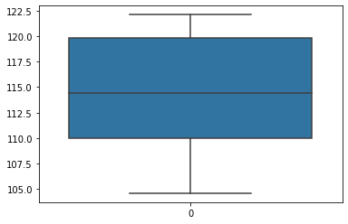

```python
# Plot range of values for Offensive ratings of our top 25 players
sns.boxplot(data=ortg_df)
```

According to the above plot (and the ORTG average), a good range for a player to be in when it comes to determining if their impact on offense is close to that of a star is to have an offensive rating of about 114-115 (or more broadly speaking 110-120 range as seen by the above plot) and a versatility index of about 11-12. If you were to look a little deeper, you would see that the top 7-8 players follow these VI stat trends very closely as well and that the elite of the elite tend to be in the >= 10 VI index range.

# 4) Defining VI and ORTG

So now that we have isolated our top players we should now look a little deeper into trends amongst these top players that allow for these numbers. Remember that versatility index measures how well a player produces points, assists, and rebounds and that Offensive rating measures the number of points produced by a player per 100 total individual possessions. So we will look into stats that will help define these two statistics.

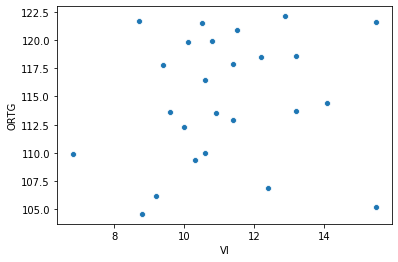

```python
# Illustrate relationship between VI and Offensive rating
sns.scatterplot(data=top_25, x='VI', y='ORTG')
```

This is the main relationship I will look into, and analysze what actually defines the VI statistic as well as how a player could improve this statistic.

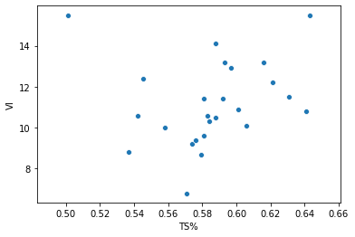

```python
sns.scatterplot(data=top_25,x='TS%',y='VI')
```

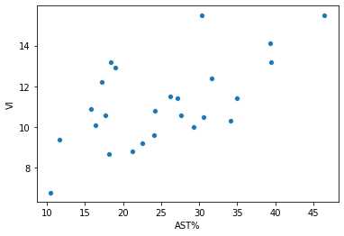

```python
# Illustrate the relationship between AST% and VI
sns.scatterplot(data=top_25,x='AST%',y='VI')
```

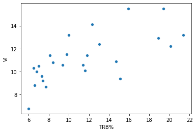

```python
# Illustrate the relationship between TRB% and VI
sns.scatterplot(data=top_25,x='TRB%',y='VI')
```

## 4.1) TS% (True Shooting Percentage)

According to the legend TS% is defined is a measure of shooting efficiency that takes into account field goals, 3-point field goals, and free throws. This is a crucial statistic in not only determining how well a player can score but also how efficiently they can score. Scoring efficiency is paramount for elite players because the key is to score in the flow of the game as opposed to completely making the offense a standstill as a player becomes a one-man wrecking crew. Scoring efficiency is also important because it doesn't take possesions and scoring opportunities away from other teammates. This becomes critical when it comes to building team chemistry as teammates of an extremely ball dominant and inefficient scorer are more likely to be more frustrated with the team and coach. Being an efficient scorer also leads to the team being more well-rounded and harder to defend as there will be multiple scoring threats (due to increased scoring opportunities for supporting players) on teams with elite, efficient scorers.

```python
ts_perc = pd.DataFrame(data = top_25['TS%'])
```

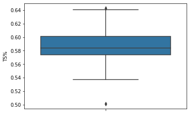

```python
# The distribution of true shooting percentage statistic
sns.boxplot(data=ts_perc,y='TS%')
```

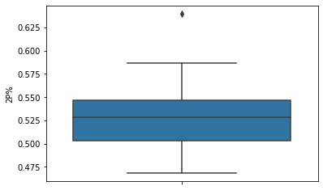

```python
# Distribution of 2-point shooting percentage
sns.boxplot(data=top_25,y='2P%')
```

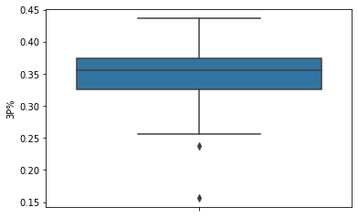

```python
# Distribution of 3-point shooting percentage
sns.boxplot(data=top_25,y='3P%')
```

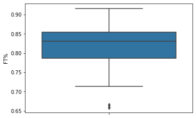

```python
# Distribution of free-throw percentage
sns.boxplot(data=top_25,y='FT%')
```

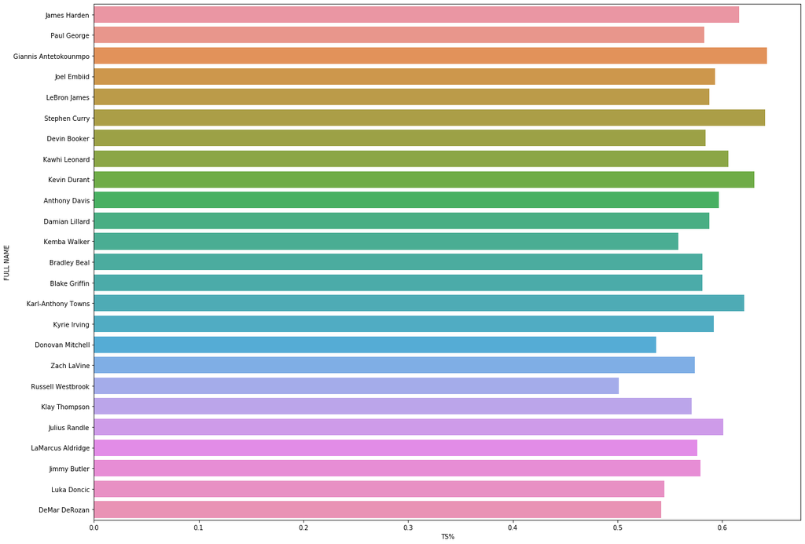

```python
plt.figure(figsize = (20, 15))
sns.barplot(data=top_25, x='TS%', y = 'FULL NAME')
```

From these graphs you can tell that a good true shooting percentage a player should aim for is at about 58-59%.

So how can a player develop these shooting numbers?

Players who shoot in this true percentage rate shoot on average of in low to mid 50s% rate from 2-point range and about mid to upper 30s% from 3-point range. Interestingly free throw percentage for these elite players happen to also be low to mid 80%s range. *From the last bar graph you can see that shooting at a true percentage of at least 60% really distingushes a player from the rest.*

*Note: Free throws are shot when a player is fouled in the act of shooting. To shoot a free throw players shoot anywhere from 1-3 shots unimpeded at the free throw line. Free throws are an extremely important skill to have as a player because elite players often times in close games tend to drive hard to the basket in the hope to get fouled and get free throws. If a certain player is known to be a good,respectable free throw shooter the way the opposing team defends this player will change completely. Poor free throw shooters are known to be exploited where teams will intentionally foul that player knowing that the chances that they make their free throws are low.*

## 4.2) Assists and Rebounds Per Game

Assists and rebounds are the other key components for versatility index.

Assists are attributed to a player who passes the ball to a teammate in such a way leading to a score by field goal. The teammate receiving the assist usually can take at most 2 dribbles with the ball; after that the scoring player is is known to have scored unassisted. Assists are crucial to the game of basketball because they are a descriptive statistic as to how responsible a player is in running the team's offense and how well they get other teammates involved in the game. The general trend over the years has been to have the point guard to handle most of the ball handling duties and therefore rack up the most assists on the team. However as teams started focusing on building more versatile players, they have began emphasizing development of their centers and power forwards passing and playmaking abilities.

Rebounds are another descriptive statistic on offense and a skill that has become devalued in this era of shooting. Rebounds are credited to a player who secures the basketball upon a missed basket, this can be either after the offensive team misses or the defensive team misses. Being a dominant rebounder is actually paramount to a team not only because it keeps the other team from scoring, but also because it gives the offensive team more possesions to score. Considering how today's game is extremely fast-paced these rebounds really end up having an effect on team scoring.

To analyze these skills I will be taking the Assist Percentage and Rebound Percentage. These statistics are defined as:

- an estimated percentage of teammate field goals a player assisted
- an estimated percentage of available rebounds grabbed by the player while the player is on the court.

### 4.2.a) Assists

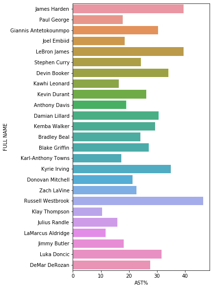

```python
# View distribution of Assist percentage among these players
plt.figure(figsize = (5,10))
sns.barplot(data=top_25,x='AST%', y='FULL NAME')
```

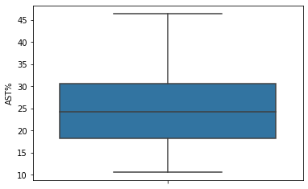

```python
# View distribution of what the distribution of these percentages are
sns.boxplot(data=top_25, y='AST%')
```

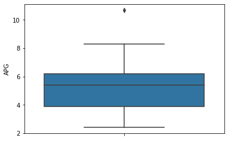

```python
sns.boxplot(data=top_25, y='APG')
```

**So as you can see here a good range to be in for assist percentage is the 20-30% range. This would imply around 5 assists per game.**

```python
# Make a dataframe with the top centers of the league
forwards_df = top_25[top_25['POS'] == 'F-C']
forwards_df
```

|  | FULL NAME | TEAM | POS | AGE | GP | MPG | MIN% | USG% | Tor | FTA | FT% | 2PA | 2P% | 3PA | 3P% | eFG% | TS% | PPG | RPG | TRB% | APG | AST% | SPG | BPG | TOPG | VI | ORTG | DRTG |
| --- | --- | --- | --- | --- | --- | --- | --- | --- | --- | --- | --- | --- | --- | --- | --- | --- | --- | --- | --- | --- | --- | --- | --- | --- | --- | --- | --- | --- |
| 3 | Joel Embiid | Phi | F-C | 25.07 | 64 | 33.7 | 70.1 | 33.3 | 13.3 | 649 | 0.804 | 936 | 0.535 | 263 | 0.3 | 0.517 | 0.593 | 27.5 | 13.6 | 21.4 | 3.7 | 18.4 | 0.72 | 1.91 | 3.55 | 13.2 | 113.7 | 98.7 |
| 9 | Anthony Davis | Nor | F-C | 26.09 | 56 | 33 | 68.8 | 29.5 | 8.5 | 433 | 0.794 | 881 | 0.547 | 145 | 0.331 | 0.54 | 0.597 | 25.9 | 12 | 18.9 | 3.9 | 19 | 1.57 | 2.41 | 2.02 | 12.9 | 122.1 | 104.5 |
| 14 | Karl-Anthony Towns | Min | F-C | 23.4 | 77 | 33 | 68.9 | 29 | 13.7 | 450 | 0.836 | 960 | 0.561 | 355 | 0.4 | 0.572 | 0.621 | 24.4 | 12.4 | 20.1 | 3.4 | 17.2 | 0.88 | 1.62 | 3.13 | 12.2 | 118.5 | 100.6 |

### 4.2.b) Rebounds

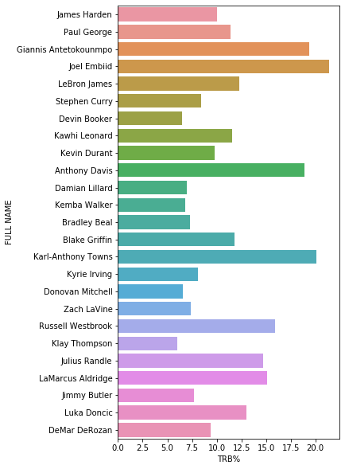

```python
# View distribution of Total rebound percentage among these players
plt.figure(figsize = (5,10))
sns.barplot(data=top_25,x='TRB%', y='FULL NAME')
```

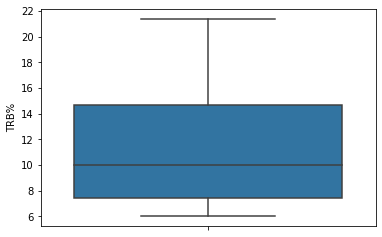

```python
# View distribution of what the distribution of these percentages are
sns.boxplot(data=top_25, y='TRB%')
```

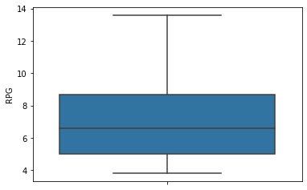

```python
# View distribution of Rebounds per game statistic
sns.boxplot(data=top_25, y='RPG')
```

```python
forwards_df
```

|  | FULL NAME | TEAM | POS | AGE | GP | MPG | MIN% | USG% | Tor | FTA | FT% | 2PA | 2P% | 3PA | 3P% | eFG% | TS% | PPG | RPG | TRB% | APG | AST% | SPG | BPG | TOPG | VI | ORTG | DRTG |
| --- | --- | --- | --- | --- | --- | --- | --- | --- | --- | --- | --- | --- | --- | --- | --- | --- | --- | --- | --- | --- | --- | --- | --- | --- | --- | --- | --- | --- |
| 3 | Joel Embiid | Phi | F-C | 25.07 | 64 | 33.7 | 70.1 | 33.3 | 13.3 | 649 | 0.804 | 936 | 0.535 | 263 | 0.3 | 0.517 | 0.593 | 27.5 | 13.6 | 21.4 | 3.7 | 18.4 | 0.72 | 1.91 | 3.55 | 13.2 | 113.7 | 98.7 |
| 9 | Anthony Davis | Nor | F-C | 26.09 | 56 | 33 | 68.8 | 29.5 | 8.5 | 433 | 0.794 | 881 | 0.547 | 145 | 0.331 | 0.54 | 0.597 | 25.9 | 12 | 18.9 | 3.9 | 19 | 1.57 | 2.41 | 2.02 | 12.9 | 122.1 | 104.5 |
| 14 | Karl-Anthony Towns | Min | F-C | 23.4 | 77 | 33 | 68.9 | 29 | 13.7 | 450 | 0.836 | 960 | 0.561 | 355 | 0.4 | 0.572 | 0.621 | 24.4 | 12.4 | 20.1 | 3.4 | 17.2 | 0.88 | 1.62 | 3.13 | 12.2 | 118.5 | 100.6 |

```python
round(top_25['USG%'].mean(),2)
```

```
30.08
```

```python
round(top_25['MPG'].mean(),2)
```

```
34.37
```

**As seen by the analysis of these offensive statistics, it's clear why certain offensive statistical trends lead to greater offensive success and production. In addition to all of that, it is important to note that all of these players are sustaining such impressive numbers while being the most or one of the most utilized players on the team. The average usage rate (an estimate of the percentage of team plays used by a player while he was on the floor) on average is at 30% which is very high considering how per game only about 8-9 players get significant playing time. Another statistic to note is that all of these players average about 34 minutes out of 48, which is well over the majority of the game.**

# 5) Model Creation

So for the models we will be making we'll will focus on the stats mentioned above to predict VI. Our goal is to have a model to use in order to predict the VI of developing players to see whether their trajectory of their path to becoming a star.

```python
# Make a model to predict VI based off of AST%, TS%, TRB%
td = top_25[['TS%','AST%','TRB%']]
tr = top_25['VI']
```

```python
target_data = td.to_numpy()
target_result = tr.to_numpy()
```

```python
# Make a linear regression model taking AST%, TS%, TRB% as inputs predicting VI
vi_lm = LinearRegression()
vi_lm.fit(target_data,target_result)
```

```
LinearRegression(copy_X=True, fit_intercept=True, n_jobs=None, normalize=False)
```

```python
# Cross-validate model to see how well it actually my VI model predicts VI
lr_scores = cross_val_score(LinearRegression(),target_data,target_result,cv=5)
```

```python
# View the scores after each round
lr_scores
```

```
array([0.90893439, 0.7895236 , 0.78505266, 0.98948179, 0.93905295])
```

```python
# Find average score of the cross validation.  This gives an idea of
# accurate the model is
lr_scores.mean()
```

```
0.8824090791744521
```

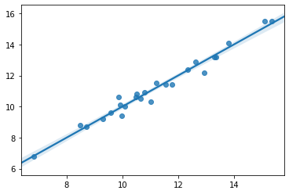

```python
# Visual depiction as to how well the model predicts VI
predicted_vi = vi_lm.predict(target_data)
sns.regplot(x=predicted_vi,y=target_result)
```

### Our model has an accuracy rating of about 88%

# 6) Conclusions

Throughout the course of this tutorial, we have looked into what skills players should focus on in order to improve their offensive skill set. We have shown which trends organizations should follow when developing franchise superstar players i.e. ideal ranges for true shooting percentages, assist percentages, etc.. We have also made a model where in an organization could plug a certain players parameters in and output what their most likely versatility index is.

These aren't skills that can neccesarily be developed over 1 or 2 seasons, and developing these skills will require a lot of patience from organizations. However, this process can be shortened if organizations are able to use analytics properly because it will help point out trends based off of empirical data showing what defines the superstars from the normal players in the league. Analytics is also important in that they can really help organizations determine how to construct and develop ideal rosters/lineups

Using analytics effectively is also important for talent scouting too. College scouts are another position NBA organizations have heavily invested in. The function of these scouts is to evaluate college players eligible for the upcoming year's draft and whether it's worth investing in them for the considerable future especially considering how valuable a draft pick is to a team. NBA organizations often time miss out on big time talent in the draft because of misevaluations of talent/skill of these young players. For example, Superstar college players often times don't pan out in the NBA because they aren't capable of handling the workload/usage rate of that of NBA stars. When asked to take on bigger roles in offenses in the NBA there is a good chance they become drastically more inefficient. Some organizations who draft these draft busts learn the hard way as to how important scouting and talent evaluation is. However, on the other hand there are other organizations who use analytics to dive deeper into player statistics to find who is most likely to succeed in the league based off many factors. This is a lot better in the long run because teams who follow these principles are less likely to waste valuable draft picks on busts.

To make a long story short, analytics especially in the NBA should be seen as a valuable tool for every single organization looking to build a successful franchise.